# Project 1: Wrangling, Exploration, Visualization

SDS322E

11/1/2021

## Data Wrangling, Exploration, Visualization

### Anastasia Nekrashevych, an26692

#### Introduction

To measure the happiness of a country, I will be using the World Happiness report from multiple years I found on Kaggle. The report attempts to measure the happiness of a country through the landmark survey conducted by Gallup World Poll. Participants from all countries are asked to think of a ladder where the highest part is marked as 10 and represents their ideal life. Then, they are asked to give a number regarding where they believe they are on the ladder. Additionally, the participants are asked how much they smiled and were happy yesterday and/or frowned and were upset. These metrics are put in percentage variables as the positive affect and the negative affect of a country. Aside from these variables, the report also provides other metrics such as how free individuals feel to make their own decisions in life. I will use the World Happiness report and add it to the alcohol consumption rate, life expectancy, suicide rate, urban percentage of population, and suicide rate of countries. These variables I will combine together from data I find on Gapminder.

My initial hypothesis is that there will be no correlation between alcohol consumption and happiness. Although alcohol consumption is known to cause negative outcomes, I suspect that the overall elevated social and economic status of western countries will outweigh the negatives. Additionally, I suspect suicide rates will not have a positive correlation with overall happiness. However, I do believe there will be a correlation when Europe is studied separately. Although there are factors beyond those being studied that influence the mental well-being of a country, I am interested in seeing how alcohol consumption, life expectancy, suicide rate, and urban population are correlated with themselves and with alcohol.

```r
# read your datasets in here, e.g., with read_csv()
library(tidyverse)
library(readr)

alcohol_consumption <- read_csv("alcohol_who.csv")
life_expectancy <- read_csv("life_expectancy_years.csv")
suicide_rate <- read_csv("suicide_per_100000_people.csv")
urban_pop <- read_csv("urban_population_percent_of_total.csv")
happiness <- read_csv("world-happiness-report.csv")
```

#### Tidying: Reshaping

To tidy my data, I began by using pivot_longer in the urban population, life expectancy, and suicide rate data to create a year variable. Then I renamed the variables to fit my liking and changed the variable year from a character to a double. For the happiness dataset I removed the variable “Healthy life expectancy at birth” because I already had life expectancy data and renamed the variables to my liking. Lastly, for the alcohol_consumption dataset, I removed the gender variable by filtering when the data is marked as “Both sexes”, chose four variables that could be effectively used for analysis, renamed the variables to my liking, and moved the country column to the beginning of the dataset.

```r
# World Happiness Report
happiness <- happiness %>% select(-"Healthy life expectancy at birth") %>%
    rename(Country = "Country name") %>% rename(Year = year)


# Alcohol consumption
alcohol_consumption <- alcohol_consumption %>% filter(Dim1 ==
    "Both sexes") %>% select(ParentLocation, Location, Period,
    FactValueNumeric) %>% rename(Country = Location) %>% rename(Region = ParentLocation) %>%
    rename(Year = Period) %>% rename(`Alcohol Liters per Person` = FactValueNumeric) %>%
    select(Country, everything())


# Suicide rate
suicide_rate <- suicide_rate %>% pivot_longer(-1, names_to = "Year") %>%
    rename(Country = country) %>% rename(`Suicides per 100,000` = value) %>%
    mutate(across(Year, as.double))


# Urban population percentage of total
urban_pop <- urban_pop %>% pivot_longer(-1, names_to = "Year") %>%
    rename(Country = country) %>% rename(`Urban Percentage of Population` = value) %>%
    mutate(across(Year, as.double))


# Life expectancy
life_expectancy <- life_expectancy %>% pivot_longer(-1, names_to = "Year") %>%
    rename(Country = country) %>% rename(`Life Expectancy` = value) %>%
    mutate(across(Year, as.double))
```

#### Joining/Merging

```r
alc_metrics <- alcohol_consumption %>% left_join(life_expectancy,
    by = c("Country", "Year")) %>% left_join(urban_pop, by = c("Country",
    "Year")) %>% left_join(suicide_rate, by = c("Country", "Year"))

full_dataset <- happiness %>% left_join(alc_metrics, by = c("Country",
    "Year"))
```

I began merging my datasets by joining alcohol_consumption to life_expectancy, urban_pop, and suicide_rate. Alcohol_consumption has 3746 observations and 4 variables. The other three datasets have more observations, because they cover a larger number of years. However, other than year and country, they only contain one variable. Since each dataset contained the variables year and country, I decided to use them as identifiers. This allows me to analyze the behavior of each specific country’s variables through time and provides a better picture of how the variables behave. I left joined the 3 datasets to the alcohol_consumption dataset by country and year so that each row contained data for these variables and named it alc_metrics.

#### Wrangling

```r
full_dataset %>% filter(str_detect(Region, "Europe")) %>% select(`Life Ladder`,
    Country, Year) %>% arrange(`Life Ladder`)
```

```
## # A tibble: 567 x 3
##    `Life Ladder` Country   Year
##            <dbl> <chr>    <dbl>
##  1          3.68 Georgia   2006
##  2          3.71 Georgia   2007
##  3          3.80 Georgia   2009
##  4          3.84 Bulgaria  2007
##  5          3.88 Bulgaria  2011
##  6          3.91 Bulgaria  2010
##  7          3.96 Ukraine   2015
##  8          3.99 Bulgaria  2013
##  9          4.03 Ukraine   2016
## 10          4.10 Georgia   2010
## # … with 557 more rows
```

```r
full_dataset %>% mutate(`GDP per capita` = 10^(`Log GDP per capita`))
```

```
## # A tibble: 1,949 x 16
##    Country  Year `Life Ladder` `Log GDP per ca… `Social support`
##    <chr>   <dbl>         <dbl>            <dbl>            <dbl>
##  1 Afghan…  2008          3.72             7.37            0.451
##  2 Afghan…  2009          4.40             7.54            0.552
##  3 Afghan…  2010          4.76             7.65            0.539
##  4 Afghan…  2011          3.83             7.62            0.521
##  5 Afghan…  2012          3.78             7.70            0.521
##  6 Afghan…  2013          3.57             7.72            0.484
##  7 Afghan…  2014          3.13             7.72            0.526
##  8 Afghan…  2015          3.98             7.70            0.529
##  9 Afghan…  2016          4.22             7.70            0.559
## 10 Afghan…  2017          2.66             7.70            0.491
## # … with 1,939 more rows, and 11 more variables: `Freedom to make life
## #   choices` <dbl>, Generosity <dbl>, `Perceptions of corruption` <dbl>,
## #   `Positive affect` <dbl>, `Negative affect` <dbl>, Region <chr>, `Alcohol
## #   Liters per Person` <dbl>, `Life Expectancy` <dbl>, `Urban Percentage of
## #   Population` <dbl>, `Suicides per 100,000` <dbl>, `GDP per capita` <dbl>
```

```r
# Categorical variables
full_dataset %>% group_by(Country) %>% summarize(n())
```

```
## # A tibble: 166 x 2
##    Country     `n()`
##    <chr>       <int>
##  1 Afghanistan    12
##  2 Albania        13
##  3 Algeria         8
##  4 Angola          4
##  5 Argentina      15
##  6 Armenia        14
##  7 Australia      14
##  8 Austria        13
##  9 Azerbaijan     14
## 10 Bahrain        11
## # … with 156 more rows
```

```r
full_dataset %>% group_by(Year) %>% summarize(n())
```

```
## # A tibble: 16 x 2
##     Year `n()`
##    <dbl> <int>
##  1  2005    27
##  2  2006    89
##  3  2007   102
##  4  2008   110
##  5  2009   114
##  6  2010   124
##  7  2011   146
##  8  2012   142
##  9  2013   137
## 10  2014   145
## 11  2015   143
## 12  2016   142
## 13  2017   147
## 14  2018   142
## 15  2019   144
## 16  2020    95
```

```r
full_dataset %>% group_by(Region) %>% summarize(n())
```

```
## # A tibble: 7 x 2
##   Region                `n()`
##   <chr>                 <int>
## 1 Africa                  358
## 2 Americas                264
## 3 Eastern Mediterranean   177
## 4 Europe                  567
## 5 South-East Asia          95
## 6 Western Pacific         119
## 7 <NA>                    369
```

```r
# Missing Values
full_dataset %>% summarize_all(~sum(is.na(.)))
```

```
## # A tibble: 1 x 15
##   Country  Year `Life Ladder` `Log GDP per ca… `Social support` `Freedom to mak…
##     <int> <int>         <int>            <int>            <int>            <int>
## 1       0     0             0               36               13               32
## # … with 9 more variables: Generosity <int>, `Perceptions of corruption` <int>,
## #   `Positive affect` <int>, `Negative affect` <int>, Region <int>, `Alcohol
## #   Liters per Person` <int>, `Life Expectancy` <int>, `Urban Percentage of
## #   Population` <int>, `Suicides per 100,000` <int>
```

```r
# Summary Statics of Numeric Variables Life Ladder
full_dataset %>% summarize(mean_Ladder = mean(`Life Ladder`,
    na.rm = TRUE), sd_Ladder = sd(`Life Ladder`, na.rm = TRUE),
    var_Ladder = var(`Life Ladder`, na.rm = TRUE), min_Ladder = min(`Life Ladder`,
        na.rm = TRUE), max_Ladder = max(`Life Ladder`, na.rm = TRUE))
```

```
## # A tibble: 1 x 5
##   mean_Ladder sd_Ladder var_Ladder min_Ladder max_Ladder
##         <dbl>     <dbl>      <dbl>      <dbl>      <dbl>
## 1        5.47      1.12       1.24       2.38       8.02
```

```r
full_dataset %>% group_by(Region) %>% summarize(mean_Ladder = mean(`Life Ladder`,
    na.rm = TRUE), sd_Ladder = sd(`Life Ladder`, na.rm = TRUE),
    var_Ladder = var(`Life Ladder`, na.rm = TRUE), min_Ladder = min(`Life Ladder`,
        na.rm = TRUE), max_Ladder = max(`Life Ladder`, na.rm = TRUE)) %>%
    arrange(mean_Ladder) %>% knitr::kable()
```

| Region | mean_Ladder | sd_Ladder | var_Ladder | min_Ladder | max_Ladder |
| --- | --- | --- | --- | --- | --- |
| Africa | 4.310751 | 0.6411995 | 0.4111368 | 2.693 | 6.355 |
| South-East Asia | 4.897063 | 0.6733186 | 0.4533579 | 3.249 | 6.985 |
| Eastern Mediterranean | 5.254492 | 1.0204667 | 1.0413523 | 2.375 | 7.267 |
| NA | 5.501989 | 1.0172291 | 1.0347550 | 2.688 | 7.889 |
| Western Pacific | 5.801294 | 1.0582317 | 1.1198543 | 3.569 | 7.604 |
| Europe | 5.972961 | 1.0173281 | 1.0349566 | 3.675 | 8.019 |
| Americas | 6.094080 | 0.8118033 | 0.6590246 | 3.352 | 7.650 |

```r
# Log GDP per capita
full_dataset %>% summarize(mean_LogGDP = mean(`Log GDP per capita`,
    na.rm = TRUE), sd_LogGDP = sd(`Log GDP per capita`, na.rm = TRUE),
    var_LogGDP = var(`Log GDP per capita`, na.rm = TRUE), min_LogGDP = min(`Log GDP per capita`,
        na.rm = TRUE), max_LogGDP = max(`Log GDP per capita`,
        na.rm = TRUE))
```

```
## # A tibble: 1 x 5
##   mean_LogGDP sd_LogGDP var_LogGDP min_LogGDP max_LogGDP
##         <dbl>     <dbl>      <dbl>      <dbl>      <dbl>
## 1        9.37      1.15       1.33       6.64       11.6
```

```r
full_dataset %>% group_by(Region) %>% summarize(mean_LogGDP = mean(`Log GDP per capita`,
    na.rm = TRUE), sd_LogGDP = sd(`Log GDP per capita`, na.rm = TRUE),
    var_LogGDP = var(`Log GDP per capita`, na.rm = TRUE), min_LogGDP = min(`Log GDP per capita`,
        na.rm = TRUE), max_LogGDP = max(`Log GDP per capita`,
        na.rm = TRUE)) %>% arrange(desc(mean_LogGDP)) %>% knitr::kable()
```

| Region | mean_LogGDP | sd_LogGDP | var_LogGDP | min_LogGDP | max_LogGDP |
| --- | --- | --- | --- | --- | --- |
| Europe | 10.132688 | 0.7623091 | 0.5811151 | 7.554 | 11.648 |
| Western Pacific | 9.818521 | 1.0390054 | 1.0795322 | 7.746 | 11.490 |
| Eastern Mediterranean | 9.507221 | 1.1098581 | 1.2317851 | 7.370 | 11.553 |
| NA | 9.460655 | 1.0662511 | 1.1368915 | 6.728 | 11.323 |
| Americas | 9.432266 | 0.6961615 | 0.4846408 | 7.384 | 10.800 |
| South-East Asia | 8.728021 | 0.6472765 | 0.4189669 | 7.616 | 9.826 |
| Africa | 7.977542 | 0.8112656 | 0.6581519 | 6.635 | 10.043 |

```r
# Positive affect
full_dataset %>% summarize(mean_PositiveA = mean(`Positive affect`,
    na.rm = TRUE), sd_PositiveA = sd(`Positive affect`, na.rm = TRUE),
    var_PositiveA = var(`Positive affect`, na.rm = TRUE), min_PositiveA = min(`Positive affect`,
        na.rm = TRUE), max_PositiveA = max(`Positive affect`,
        na.rm = TRUE))
```

```
## # A tibble: 1 x 5
##   mean_PositiveA sd_PositiveA var_PositiveA min_PositiveA max_PositiveA
##            <dbl>        <dbl>         <dbl>         <dbl>         <dbl>
## 1          0.710        0.107        0.0115         0.322         0.944
```

```r
full_dataset %>% group_by(Region) %>% summarize(mean_PositiveA = mean(`Positive affect`,
    na.rm = TRUE), sd_PositiveA = sd(`Positive affect`, na.rm = TRUE),
    var_PositiveA = var(`Positive affect`, na.rm = TRUE), min_PositiveA = min(`Positive affect`,
        na.rm = TRUE), max_PositiveA = max(`Positive affect`,
        na.rm = TRUE)) %>% arrange(desc(mean_PositiveA)) %>%
    knitr::kable()
```

| Region | mean_PositiveA | sd_PositiveA | var_PositiveA | min_PositiveA | max_PositiveA |
| --- | --- | --- | --- | --- | --- |
| Americas | 0.8145189 | 0.0637307 | 0.0040616 | 0.538 | 0.944 |
| Western Pacific | 0.7822797 | 0.0736778 | 0.0054284 | 0.483 | 0.891 |
| South-East Asia | 0.7499677 | 0.1069492 | 0.0114381 | 0.536 | 0.934 |
| NA | 0.6979809 | 0.0998587 | 0.0099718 | 0.369 | 0.917 |
| Europe | 0.6876979 | 0.1036227 | 0.0107377 | 0.422 | 0.900 |
| Africa | 0.6807591 | 0.0830565 | 0.0068984 | 0.362 | 0.838 |
| Eastern Mediterranean | 0.6340982 | 0.1096103 | 0.0120144 | 0.322 | 0.901 |

```r
# Negative affect
full_dataset %>% summarize(mean_NegativeA = mean(`Negative affect`,
    na.rm = TRUE), sd_NegativeA = sd(`Negative affect`, na.rm = TRUE),
    var_NegativeA = var(`Negative affect`, na.rm = TRUE), min_NegativeA = min(`Negative affect`,
        na.rm = TRUE), max_NegativeA = max(`Negative affect`,
        na.rm = TRUE))
```

```
## # A tibble: 1 x 5
##   mean_NegativeA sd_NegativeA var_NegativeA min_NegativeA max_NegativeA
##            <dbl>        <dbl>         <dbl>         <dbl>         <dbl>
## 1          0.269       0.0852       0.00725         0.083         0.705
```

```r
full_dataset %>% group_by(Region) %>% summarize(mean_NegativeA = mean(`Negative affect`,
    na.rm = TRUE), sd_NegativeA = sd(`Negative affect`, na.rm = TRUE),
    var_NegativeA = var(`Negative affect`, na.rm = TRUE), min_NegativeA = min(`Negative affect`,
        na.rm = TRUE), max_NegativeA = max(`Negative affect`,
        na.rm = TRUE)) %>% arrange(desc(mean_NegativeA)) %>%
    knitr::kable()
```

| Region | mean_NegativeA | sd_NegativeA | var_NegativeA | min_NegativeA | max_NegativeA |
| --- | --- | --- | --- | --- | --- |
| Eastern Mediterranean | 0.3189102 | 0.0869958 | 0.0075683 | 0.095 | 0.591 |
| NA | 0.2787820 | 0.1009434 | 0.0101896 | 0.083 | 0.705 |
| Americas | 0.2775114 | 0.0506805 | 0.0025685 | 0.134 | 0.420 |
| Africa | 0.2741961 | 0.0929275 | 0.0086355 | 0.109 | 0.599 |
| Europe | 0.2514470 | 0.0738737 | 0.0054573 | 0.103 | 0.482 |
| South-East Asia | 0.2493404 | 0.0694700 | 0.0048261 | 0.112 | 0.466 |
| Western Pacific | 0.2255678 | 0.0844023 | 0.0071238 | 0.107 | 0.482 |

```r
# Alcohol Liters per Person
full_dataset %>% summarize(mean_AlcLiters = mean(`Alcohol Liters per Person`,
    na.rm = TRUE), sd_AlcLiters = sd(`Alcohol Liters per Person`,
    na.rm = TRUE), var_AlcLiters = var(`Alcohol Liters per Person`,
    na.rm = TRUE), min_AlcLiters = min(`Alcohol Liters per Person`,
    na.rm = TRUE), max_AlcLiters = max(`Alcohol Liters per Person`,
    na.rm = TRUE))
```

```
## # A tibble: 1 x 5
##   mean_AlcLiters sd_AlcLiters var_AlcLiters min_AlcLiters max_AlcLiters
##            <dbl>        <dbl>         <dbl>         <dbl>         <dbl>
## 1           6.15         4.38          19.2             0          16.7
```

```r
full_dataset %>% group_by(Country, Year) %>% summarize(mean_AlcLiters = mean(`Alcohol Liters per Person`,
    na.rm = TRUE), min_AlcLiters = min(`Alcohol Liters per Person`,
    na.rm = TRUE), max_AlcLiters = max(`Alcohol Liters per Person`,
    na.rm = TRUE), Vodka_Handles = `Alcohol Liters per Person`/1.75) %>%
    arrange(desc(Vodka_Handles))
```

```
## # A tibble: 1,949 x 6
## # Groups:   Country [166]
##    Country     Year mean_AlcLiters min_AlcLiters max_AlcLiters Vodka_Handles
##    <chr>      <dbl>          <dbl>         <dbl>         <dbl>         <dbl>
##  1 Estonia     2006           16.7          16.7          16.7          9.53
##  2 Montenegro  2007           16.6          16.6          16.6          9.50
##  3 Montenegro  2009           16.5          16.5          16.5          9.45
##  4 Lithuania   2007           16.5          16.5          16.5          9.43
##  5 Lithuania   2006           16.5          16.5          16.5          9.41
##  6 Estonia     2007           16.4          16.4          16.4          9.37
##  7 Lithuania   2012           16.4          16.4          16.4          9.35
##  8 Lithuania   2013           16.3          16.3          16.3          9.33
##  9 Romania     2007           16.2          16.2          16.2          9.26
## 10 Romania     2005           16.0          16.0          16.0          9.14
## # … with 1,939 more rows
```

```r
# Life Expectancy
full_dataset %>% summarize(mean_LifeExp = mean(`Life Expectancy`,
    na.rm = TRUE), sd_LifeExp = sd(`Life Expectancy`, na.rm = TRUE),
    var_LifeExp = var(`Life Expectancy`, na.rm = TRUE), min_LifeExp = min(`Life Expectancy`,
        na.rm = TRUE), max_LiefExp = max(`Life Expectancy`, na.rm = TRUE))
```

```
## # A tibble: 1 x 5
##   mean_LifeExp sd_LifeExp var_LifeExp min_LifeExp max_LiefExp
##          <dbl>      <dbl>       <dbl>       <dbl>       <dbl>
## 1         72.5       7.78        60.6        46.8        84.9
```

```r
full_dataset %>% group_by(Region) %>% summarize(mean_LifeExp = mean(`Life Expectancy`,
    na.rm = TRUE), sd_LifeExp = sd(`Life Expectancy`, na.rm = TRUE),
    var_LifeExp = var(`Life Expectancy`, na.rm = TRUE), min_LifeExp = min(`Life Expectancy`,
        na.rm = TRUE), max_LiefExp = max(`Life Expectancy`, na.rm = TRUE)) %>%
    arrange(desc(mean_LifeExp)) %>% knitr::kable()
```

| Region | mean_LifeExp | sd_LifeExp | var_LifeExp | min_LifeExp | max_LiefExp |
| --- | --- | --- | --- | --- | --- |
| Europe | 77.39114 | 4.666108 | 21.77256 | 65.3 | 84.0 |
| Western Pacific | 76.50504 | 6.429419 | 41.33743 | 64.5 | 84.9 |
| Americas | 75.51705 | 4.168446 | 17.37594 | 60.0 | 82.4 |
| South-East Asia | 72.01158 | 3.607700 | 13.01550 | 65.8 | 79.1 |
| Eastern Mediterranean | 71.90734 | 5.602222 | 31.38489 | 57.0 | 81.6 |
| Africa | 62.04274 | 5.206335 | 27.10593 | 46.8 | 76.2 |
| NA | NaN | NA | NA | Inf | -Inf |

```r
# Urban Percentage of Population
full_dataset %>% summarize(mean_UrbanPop = mean(`Urban Percentage of Population`,
    na.rm = TRUE), sd_UrbanPop = sd(`Urban Percentage of Population`,
    na.rm = TRUE), var_UrbanPop = var(`Urban Percentage of Population`,
    na.rm = TRUE), min_UrbanPop = min(`Urban Percentage of Population`,
    na.rm = TRUE), max_UrbanPop = max(`Urban Percentage of Population`,
    na.rm = TRUE))
```

```
## # A tibble: 1 x 5
##   mean_UrbanPop sd_UrbanPop var_UrbanPop min_UrbanPop max_UrbanPop
##           <dbl>       <dbl>        <dbl>        <dbl>        <dbl>
## 1          60.3        22.3         498.         10.4          100
```

```r
full_dataset %>% group_by(Country) %>% summarize(mean_UrbanPop = mean(`Urban Percentage of Population`,
    na.rm = TRUE), sd_UrbanPop = sd(`Urban Percentage of Population`,
    na.rm = TRUE), var_UrbanPop = var(`Urban Percentage of Population`,
    na.rm = TRUE), min_UrbanPop = min(`Urban Percentage of Population`,
    na.rm = TRUE), max_UrbanPop = max(`Urban Percentage of Population`,
    na.rm = TRUE))
```

```
## # A tibble: 166 x 6
##    Country     mean_UrbanPop sd_UrbanPop var_UrbanPop min_UrbanPop max_UrbanPop
##    <chr>               <dbl>       <dbl>        <dbl>        <dbl>        <dbl>
##  1 Afghanistan          24.7       0.821       0.675          23.5         26
##  2 Albania              56.7       3.79       14.4            50           62.1
##  3 Algeria              71.1       2.07        4.29           68.2         73.7
##  4 Angola               62.4       0.904       0.817          61.3         63.4
##  5 Argentina            91.3       0.554       0.306          90.4         92.1
##  6 Armenia              63.3       0.201       0.0403         63.1         63.7
##  7 Australia            85.6       0.463       0.214          84.7         86.2
##  8 Austria              57.8       0.533       0.284          57.1         58.7
##  9 Azerbaijan           54.4       1.16        1.34           52.8         56.4
## 10 Bahrain              89.0       0.285       0.081          88.6         89.5
## # … with 156 more rows
```

```r
# Suicides per 100,000
full_dataset %>% summarize(mean_Suicides = mean(`Suicides per 100,000`,
    na.rm = TRUE), sd_Suicides = sd(`Suicides per 100,000`, na.rm = TRUE),
    var_Suicides = var(`Suicides per 100,000`, na.rm = TRUE),
    min_Suicides = min(`Suicides per 100,000`, na.rm = TRUE),
    max_Suicides = max(`Suicides per 100,000`, na.rm = TRUE))
```

```
## # A tibble: 1 x 5
##   mean_Suicides sd_Suicides var_Suicides min_Suicides max_Suicides
##           <dbl>       <dbl>        <dbl>        <dbl>        <dbl>
## 1          9.29        5.95         35.4       0.0578         30.9
```

```r
full_dataset %>% filter(Region != "Americas") %>% group_by(Country,
    Year) %>% summarize(mean_Suicides = mean(`Suicides per 100,000`,
    na.rm = TRUE), sd_Suicides = sd(`Suicides per 100,000`, na.rm = TRUE),
    var_Suicides = var(`Suicides per 100,000`, na.rm = TRUE),
    min_Suicides = min(`Suicides per 100,000`, na.rm = TRUE),
    max_Suicides = max(`Suicides per 100,000`, na.rm = TRUE)) %>%
    arrange(desc(mean_Suicides))
```

```
## # A tibble: 1,316 x 7
## # Groups:   Country [116]
##    Country  Year mean_Suicides sd_Suicides var_Suicides min_Suicides
##    <chr>   <dbl>         <dbl>       <dbl>        <dbl>        <dbl>
##  1 Lithua…  2012          30.9          NA           NA         30.9
##  2 Lithua…  2008          30.4          NA           NA         30.4
##  3 Lithua…  2007          30.1          NA           NA         30.1
##  4 Lithua…  2010          28            NA           NA         28
##  5 Lithua…  2009          27.6          NA           NA         27.6
##  6 Lithua…  2006          27.4          NA           NA         27.4
##  7 Lithua…  2013          26.1          NA           NA         26.1
##  8 Lithua…  2011          25.7          NA           NA         25.7
##  9 Lithua…  2014          25.2          NA           NA         25.2
## 10 Lithua…  2015          22.9          NA           NA         22.9
## # … with 1,306 more rows, and 1 more variable: max_Suicides <dbl>
```

```r
full_dataset %>% group_by(Region) %>% filter(Region != "Americas") %>%
    summarize(mean_Suicides = mean(`Suicides per 100,000`, na.rm = TRUE),
        sd_Suicides = sd(`Suicides per 100,000`, na.rm = TRUE),
        var_Suicides = var(`Suicides per 100,000`, na.rm = TRUE),
        min_Suicides = min(`Suicides per 100,000`, na.rm = TRUE),
        max_Suicides = max(`Suicides per 100,000`, na.rm = TRUE),
        num_Suicides = n()) %>% arrange(desc(mean_Suicides)) %>%
    knitr::kable()
```

| Region | mean_Suicides | sd_Suicides | var_Suicides | min_Suicides | max_Suicides | num_Suicides |
| --- | --- | --- | --- | --- | --- | --- |
| Europe | 10.0524325 | 5.7539150 | 33.1075380 | 0.1150 | 30.90 | 567 |
| Western Pacific | 9.5495750 | 5.9073022 | 34.8962194 | 0.0684 | 19.10 | 119 |
| Africa | 5.9086667 | 4.2909749 | 18.4124653 | 0.9660 | 8.68 | 358 |
| South-East Asia | 5.4990000 | 0.0806157 | 0.0064989 | 5.3900 | 5.65 | 95 |
| Eastern Mediterranean | 0.6504167 | 0.5124940 | 0.2626501 | 0.0578 | 1.47 | 177 |

I began wrangling my data by doing some exploratory analysis. Understanding Europe’s political climate and culture better than elsewhere in the world, I decided to look over its data by filtering it out using a str_detect function. Then, I selected Life Ladder, Country, and Year to see which countries in Europe in which years had the highest and lowest Life Ladder scores. I also decided to reverse the log of the log GDP per capita to see what the actual GDP per capita is of all countries. Before analyzing my numerical variables, I also obtained the frequency of each categorical variable and the number of missing values of each variable.

To compute the summary statistics of my numeric variables, I first found the individual mean, standard deviation, variance, and minimum of each numeric variable. Afterwards, for each numeric variable, I computed an additional summary statistic. For the life ladder, positive affect, negative affect, life expectancy, and Log GDP per capita variables, I grouped by region to see which regions were happier, lived longer, and had a higher income. For the alcohol liters per person variable, I was curious to see which countries drank the most. I grouped by country and year, computed the normal summary statistics, and added a function for how many handles were drunk per person in a year. For the urban percentage of population variable, I grouped by country to see which countries were the most urbanized. Lastly, for the suicide rate variable, I grouped by country and year to see which countries had the worst years regarding suicide and then by region to see which regions faired the worse.

#### Visualizing

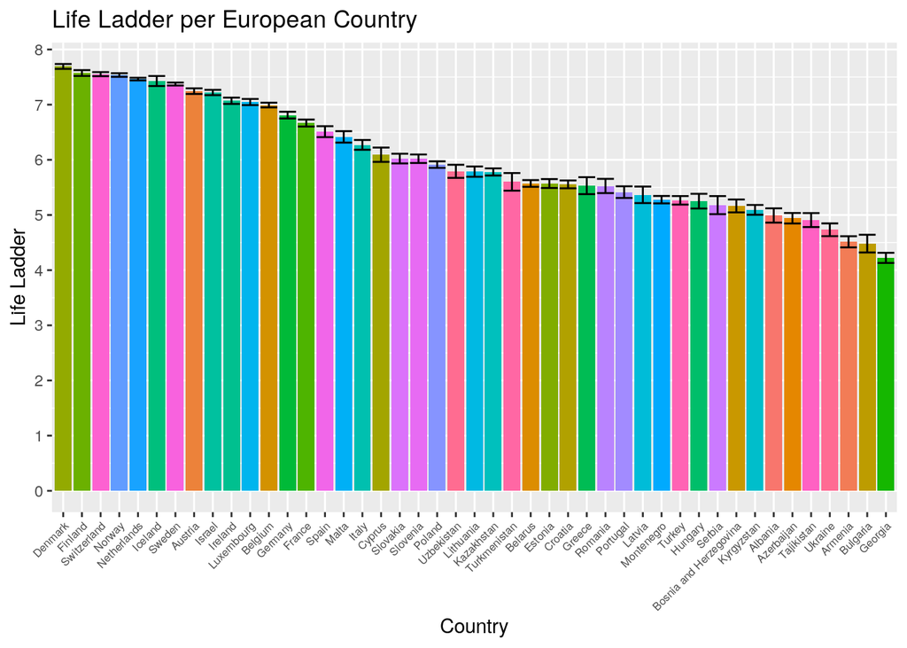

```r
library(ggplot2)

# graph including stat=summary''
full_dataset %>% filter(Region == "Europe") %>% rename(Life_Ladder = `Life Ladder`) %>%
    ggplot(aes(x = reorder(Country, -Life_Ladder), y = Life_Ladder)) +
    geom_bar(aes(y = Life_Ladder, fill = Country), stat = "summary",
        fun = mean) + geom_errorbar(stat = "summary", fun.data = mean_se) +
    ggtitle("Life Ladder per European Country") + theme(axis.text.x = element_text(angle = 45,
    hjust = 1, size = rel(0.7)), legend.position = "none") +
    scale_y_continuous(n.breaks = 10) + xlab("Country") + ylab("Life Ladder")
```

*I created a bar plot to visually see how countries in Europe compare in happiness. I plotted the variable Life Ladder on the y axis and the variable Country on the x axis. I then calculated the mean Life Ladder result of each country per year and the standard error. The results show that, in general, Western Europeans are more content with their lives and happy than Eastern Europeans.*

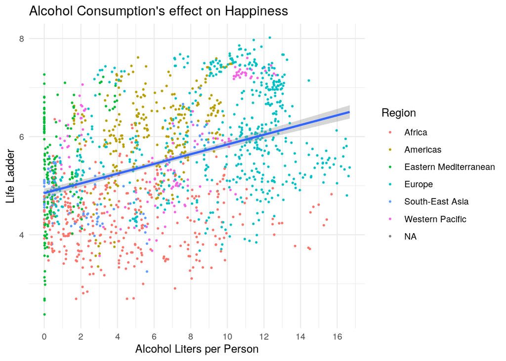

```r
full_dataset %>% rename(Alcohol_Liters = `Alcohol Liters per Person`) %>%
    rename(Life_Ladder = `Life Ladder`) %>% ggplot(aes(x = Alcohol_Liters,
    y = Life_Ladder)) + geom_point(aes(color = Region), size = 0.5) +
    geom_smooth(method = "lm") + scale_x_continuous(n.breaks = 10) +
    ggtitle("Alcohol Consumption's effect on Happiness") + xlab("Alcohol Liters per Person") +
    ylab("Life Ladder") + theme_minimal()
```

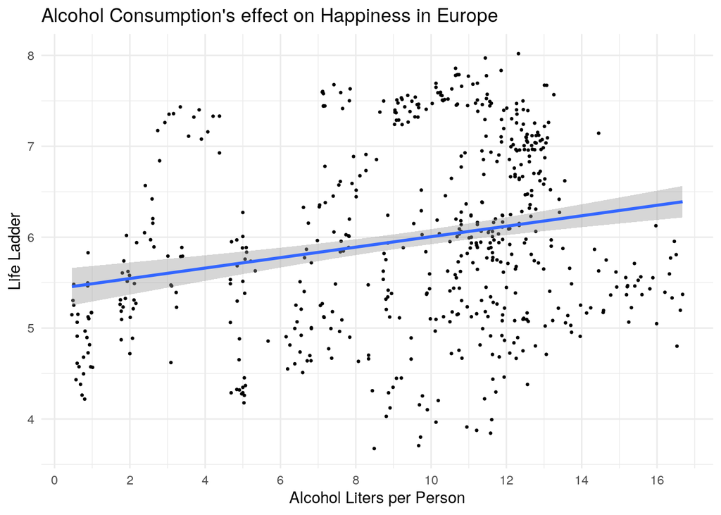

```r
full_dataset %>% filter(Region == "Europe") %>% rename(Alcohol_Liters = `Alcohol Liters per Person`) %>%
    rename(Life_Ladder = `Life Ladder`) %>% ggplot(aes(x = Alcohol_Liters,
    y = Life_Ladder)) + geom_point(size = 0.5) + geom_smooth(method = "lm") +
    scale_x_continuous(n.breaks = 10) + ggtitle("Alcohol Consumption's effect on Happiness in Europe") +
    xlab("Alcohol Liters per Person") + ylab("Life Ladder") +
    theme_minimal()
```

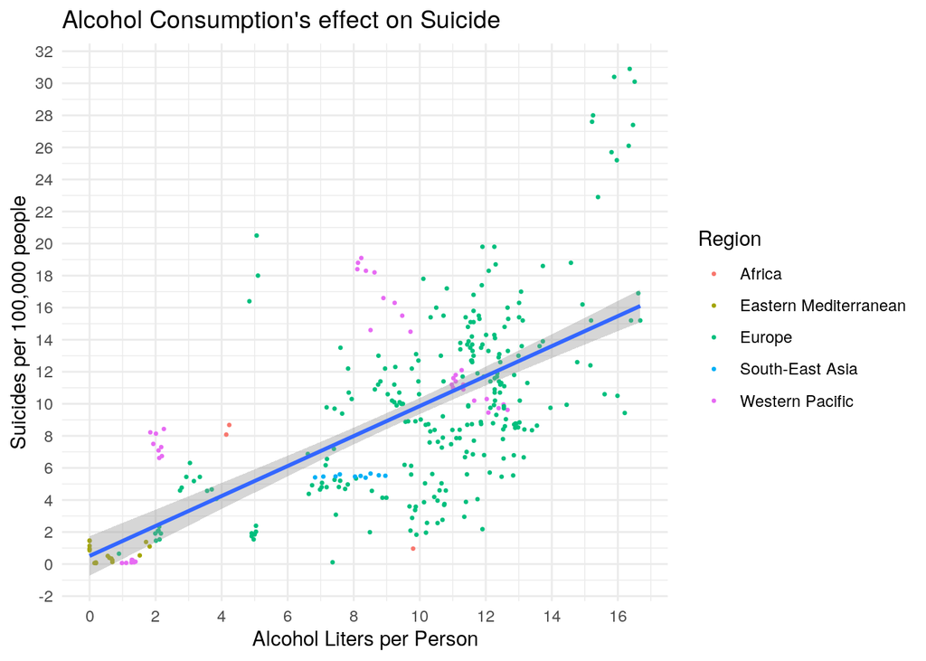

```r
full_dataset %>% filter(Region != "Americas") %>% rename(Alcohol_Liters = `Alcohol Liters per Person`) %>%
    rename(Suicide_Rate = `Suicides per 100,000`) %>% ggplot(aes(x = Alcohol_Liters,
    y = Suicide_Rate)) + geom_point(aes(color = Region), size = 0.5) +
    geom_smooth(method = "lm") + scale_y_continuous(n.breaks = 20) +
    scale_x_continuous(n.breaks = 10) + theme_minimal() + ggtitle("Alcohol Consumption's effect on Suicide") +
    xlab("Alcohol Liters per Person") + ylab("Suicides per 100,000 people")
```